# mcp

We start with some basic imports (to be edited later/by necessity).

```python
import numpy as np # linear algebra
import pandas as pd # data processing, CSV file I/O (e.g. pd.read_csv)
import os
import matplotlib.pyplot as plt
import seaborn as sns
from sklearn.preprocessing import StandardScaler
```

Next, we load in the relevant data. I am exporting a list of all potential decision variables to .csv to do a preliminary assessment of which I think will be pertinent to the problem of deciding a sale price.

```python
df_train = pd.read_csv('../input/train.csv')
df_test = pd.read_csv('../input/test.csv')

df_train.head(5)
#cols = pd.DataFrame({'Titles': list(df_train.columns)})
#cols.to_csv('column_data.csv', index=False)
```

|  | Id | MSSubClass | MSZoning | LotFrontage | LotArea | Street | Alley | LotShape | LandContour | Utilities | LotConfig | LandSlope | Neighborhood | Condition1 | Condition2 | BldgType | HouseStyle | OverallQual | OverallCond | YearBuilt | YearRemodAdd | RoofStyle | RoofMatl | Exterior1st | Exterior2nd | MasVnrType | MasVnrArea | ExterQual | ExterCond | … |
| --- | --- | --- | --- | --- | --- | --- | --- | --- | --- | --- | --- | --- | --- | --- | --- | --- | --- | --- | --- | --- | --- | --- | --- | --- | --- | --- | --- | --- | --- | --- |
| 0 | 1 | 60 | RL | 65.0 | 8450 | Pave | NaN | Reg | Lvl | AllPub | Inside | Gtl | CollgCr | Norm | Norm | 1Fam | 2Story | 7 | 5 | 2003 | 2003 | Gable | CompShg | VinylSd | VinylSd | BrkFace | 196.0 | Gd | TA | … |
| 1 | 2 | 20 | RL | 80.0 | 9600 | Pave | NaN | Reg | Lvl | AllPub | FR2 | Gtl | Veenker | Feedr | Norm | 1Fam | 1Story | 6 | 8 | 1976 | 1976 | Gable | CompShg | MetalSd | MetalSd | None | 0.0 | TA | TA | … |
| 2 | 3 | 60 | RL | 68.0 | 11250 | Pave | NaN | IR1 | Lvl | AllPub | Inside | Gtl | CollgCr | Norm | Norm | 1Fam | 2Story | 7 | 5 | 2001 | 2002 | Gable | CompShg | VinylSd | VinylSd | BrkFace | 162.0 | Gd | TA | … |
| 3 | 4 | 70 | RL | 60.0 | 9550 | Pave | NaN | IR1 | Lvl | AllPub | Corner | Gtl | Crawfor | Norm | Norm | 1Fam | 2Story | 7 | 5 | 1915 | 1970 | Gable | CompShg | Wd Sdng | Wd Shng | None | 0.0 | TA | TA | … |
| 4 | 5 | 60 | RL | 84.0 | 14260 | Pave | NaN | IR1 | Lvl | AllPub | FR2 | Gtl | NoRidge | Norm | Norm | 1Fam | 2Story | 8 | 5 | 2000 | 2000 | Gable | CompShg | VinylSd | VinylSd | BrkFace | 350.0 | Gd | TA | … |

### Heuristics

Using rough guesswork and intuition, I have decided that the following variables are most likely to affect a property's ultimate sale price:

Neighborhood, Condition1, Condition2, BldgType, OverallQual, OverallCond, ExterQual, ExterCond, CentralAir, Electrical, 1stFlrSF, 2ndFlrSF, KitchenAbvGr, KitchenQual, TotRmsAbvGrd, GarageArea, WoodDeckSF, OpenPorchSF, EnclosedPorch, and PoolArea

We will proceed with a simple analysis of our data to determine which of these variables correlate most highly with sale price.

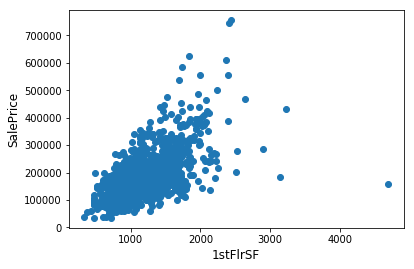

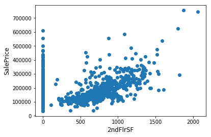

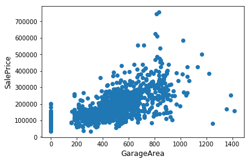

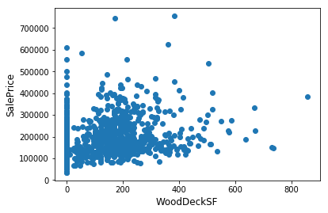

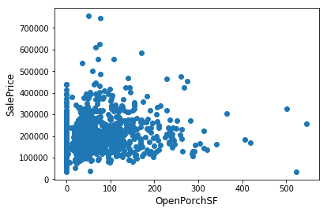

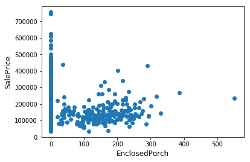

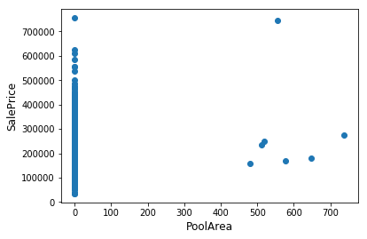

```python
num_vars = ['1stFlrSF',
            '2ndFlrSF',
            'GarageArea',
            'WoodDeckSF',
            'OpenPorchSF',
            'EnclosedPorch',
            'PoolArea']

for i in num_vars:
    x = df_train[i]
    y = df_train['SalePrice']

    plt.xlabel(i, fontsize=12)
    plt.ylabel('SalePrice', fontsize=12)

    plt.scatter(x, y)
    plt.show()
```

Of our numerical data, it seems that 1stFloorSF, 2ndFloorSF and GarageArea are most correlated with SalePrice. Now, it is entirely possible (and honestly likely) that one of the numerical variables that we eliminated in our heuristic once-over is better correlated with SalePrice than the ones we've shown here. However, I have chosen to forego that possibility and forge ahead with the (significantly) smaller subset of features. Should my future predictions prove horrendously poor, I shall certainly revisit this decision.

On to the categorical variables!

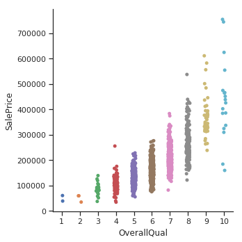

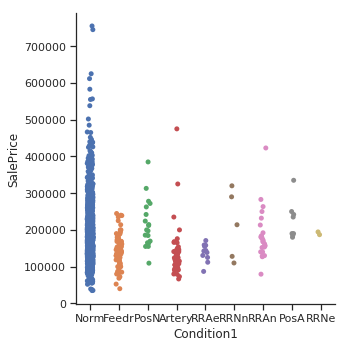

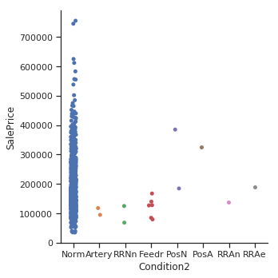

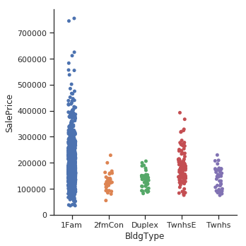

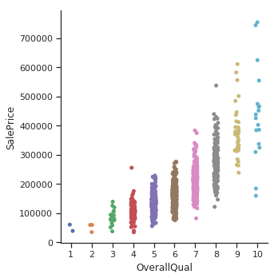

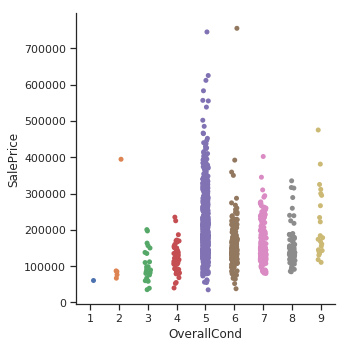

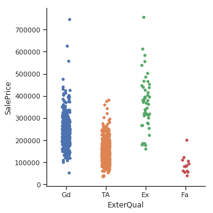

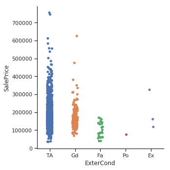

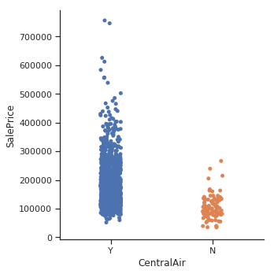

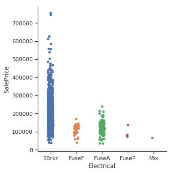

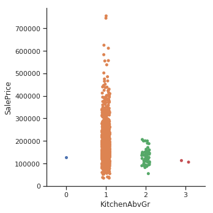

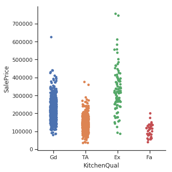

[1 more figures not shown]

```python
sns.set(style="ticks", color_codes=True)

data = df_train[['OverallQual', 'SalePrice']]
sns.catplot(x="OverallQual", y="SalePrice", data=data)

cat_data = ['Condition1',
            'Condition2',
            'BldgType',
            'OverallQual',
            'OverallCond',
            'ExterQual',
            'ExterCond',
            'CentralAir',
            'Electrical',
            'KitchenAbvGr',
            'KitchenQual',
            'TotRmsAbvGrd']

for i in cat_data:
    data = df_train[[i, 'SalePrice']]
    sns.catplot(x=i, y="SalePrice", data=data)
```

We see that (bearing in mind the same caveats held for our numerical data), of our heuristically selected categorical variables, the ones most directly correlated with SalePrice appear to be OverallQual and TotRmsAbvGrd.

### A More Legit Approach

Okay, maybe we should actually do this scientifically... (As you may have guessed, I'm following a tutorial, and at this point it was suggested that perhaps heuristics is not the most admirable approach to predictive data science. I suppose I'm inclined to agree.)

We shall start by generating a heatmap outlining the respective correlations between all of our features.

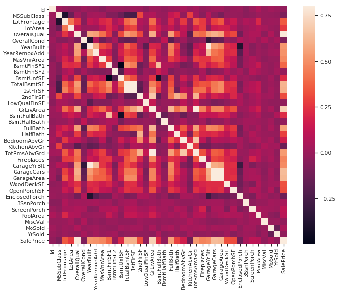

```python
corrmat = df_train.corr()
f, ax = plt.subplots(figsize=(12, 9))
sns.heatmap(corrmat, vmax=.8, square=True)
```

Let's not rely on our ability to identify colors in a heatmap to decide which variables are the most highly correlated. Seaborn allows us to select the n most correlated features and create a smaller heatmap. Let's ensure that our intuition is correct.

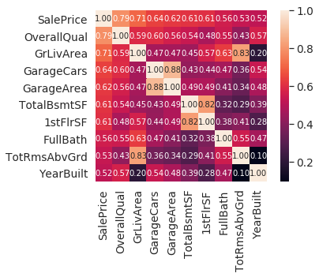

```python
k = 10
cols = corrmat.nlargest(k, 'SalePrice')['SalePrice'].index
cm = np.corrcoef(df_train[cols].values.T)
sns.set(font_scale=1.25)
hm = sns.heatmap(cm, cbar=True, annot=True, square=True, fmt='.2f', annot_kws={'size': 10}, yticklabels=cols.values, xticklabels=cols.values)
plt.show()
```

Let's do a quick sanity check to ensure that these variables make sense:

- OverallQual: Yeah, no surprise here. It's kind of a weird metric, though. What considerations were taken to determine this value? Does it overlap with other variables?
- GrLivArea: Makes sense.
- GarageCars: Seems a little odd. I mean, maybe people care a lot about car-specific garage space.
- GarageArea, TotalBsmtSF and 1stFlrSF: I get it. One question: are these values included in GrLivArea? What exactly is a "living area"?
- FullBath, TotRmsAbvGrd and YearBuilt: Seems normal; I get it, but how many people are living in bunkers?; Yup, fine.

Let's keep OverallQual, GrLivArea, GarageCars and TotalBsmtSF. (I'll admit, these choices were more than a little influenced by the tutorial I'm following.) Oh, and let's look at how these variables all compare with each other.

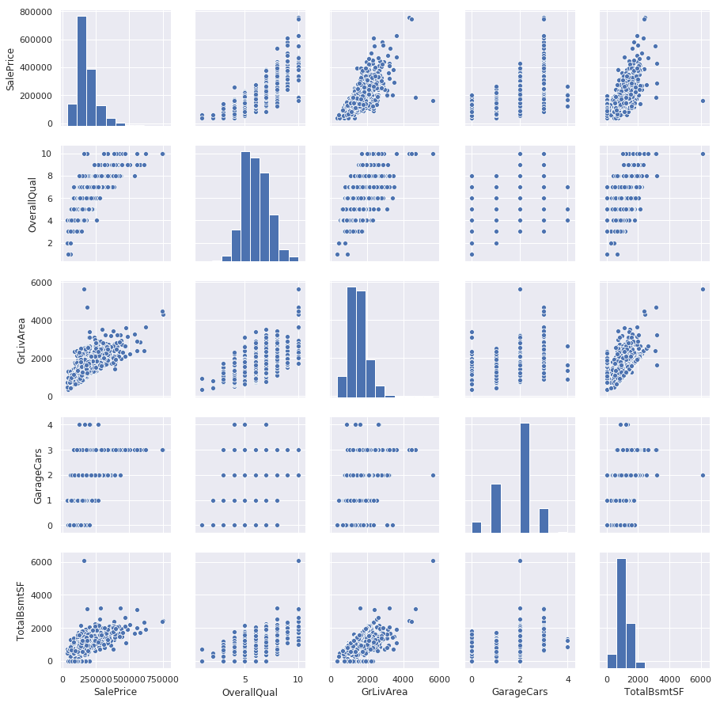

```python
sns.set()
cols = ['SalePrice', 'OverallQual', 'GrLivArea', 'GarageCars', 'TotalBsmtSF']
sns.pairplot(df_train[cols], height = 2.5)
plt.show()
```

That's pretty neat, eh? How about that one cheap house with the huge basement? Makes you wonder what they were doing down there...

### Moving Right Along

Alright! We've done some preliminary feature analysis, both heuristically and somewhat less so. We feel (hopefully) familiar with the variables we've been provided, and have chosen a subset of them on which we will focus our predictions. Let's clean up that data and move on to the fun part. (Just kidding! All of this is a fucking blast ...Right?)

We'll begin by getting an assessment of how much data is missing for each feature. This is helpful because any feature that is missing a substantially large subset of datapoints is more likely to confuse our predictions than help.

```python
total = df_train.isnull().sum().sort_values(ascending=False)
percent = (df_train.isnull().sum() / df_train.isnull().count()).sort_values(ascending=False)
missing_data = pd.concat([total, percent], axis=1, keys=['Total', 'Percent'])
missing_data.head(20)
```

|  | Total | Percent |
| --- | --- | --- |
| PoolQC | 1453 | 0.995205 |
| MiscFeature | 1406 | 0.963014 |
| Alley | 1369 | 0.937671 |
| Fence | 1179 | 0.807534 |
| FireplaceQu | 690 | 0.472603 |
| LotFrontage | 259 | 0.177397 |
| GarageCond | 81 | 0.055479 |
| GarageType | 81 | 0.055479 |
| GarageYrBlt | 81 | 0.055479 |
| GarageFinish | 81 | 0.055479 |
| GarageQual | 81 | 0.055479 |
| BsmtExposure | 38 | 0.026027 |
| BsmtFinType2 | 38 | 0.026027 |
| BsmtFinType1 | 37 | 0.025342 |
| BsmtCond | 37 | 0.025342 |
| BsmtQual | 37 | 0.025342 |
| MasVnrArea | 8 | 0.005479 |
| MasVnrType | 8 | 0.005479 |
| Electrical | 1 | 0.000685 |
| Utilities | 0 | 0.000000 |

It seems that the first 19 features all have some missing data. That's too bad. Now, if any of these features were highly correlated with SalePrice (read: if we cared), we might consider going in and replacing these null values with the mean or expected value for that feature. However, as luck would have it, none of these features are ones we decided to care about in the previous section. Let's delete 'em! (Yeah, yeah, maybe this is heavy-handed. But it's also practice and I have little desire to make this problem more complicated that it needs to be. Fuck it. Never look back.)

```python
df_train = df_train.drop((missing_data[missing_data['Total'] > 0]).index,1)
df_train.isnull().sum().max()
```

```
0
```

Now that we've removed all the features with missing data, let's deal with those datapoints that seem to fall outside of the normal trend (that is to say, the outliers). Remember that cheap house with the big basement? That didn't seem normal. Let's find all the datapoints like that.

We'll begin by standardizing the SalePrice data. This means that we will scale the prices such that the mean price is 0 and standard deviation is 1. Fortunately, sklearn can do this automatically.

```python
scaled_prices = StandardScaler().fit_transform(df_train[['SalePrice']])
low_range = scaled_prices[scaled_prices[:,0].argsort()][:10]
high_range= scaled_prices[scaled_prices[:,0].argsort()][-10:]
print('outer range (low) of the distribution:')
print(low_range)
print('\nouter range (high) of the distribution:')
print(high_range)
```

```
outer range (low) of the distribution:
[[-1.83870376]
 [-1.83352844]
 [-1.80092766]
 [-1.78329881]
 [-1.77448439]
 [-1.62337999]
 [-1.61708398]
 [-1.58560389]
 [-1.58560389]
 [-1.5731    ]]

outer range (high) of the distribution:
[[3.82897043]
 [4.04098249]
 [4.49634819]
 [4.71041276]
 [4.73032076]
 [5.06214602]
 [5.42383959]
 [5.59185509]
 [7.10289909]
 [7.22881942]]
```

We can see that in the low end of prices, things seem to be relatively consistent. This makes sense. Houses can only be so cheap; there is probably a informal glassfloor for housing prices, independent of how garbage the house is. On the high end, however, there seem to be a few outliers. Again, this is to be expected. Someone is going to try (and probably succeed at) selling their house for well over the markt price. We'll keep an eye on those.

Let's take a moment to talk about that cheap house with the big basement. That sure seemed like an outlier. Let's take a closer look.

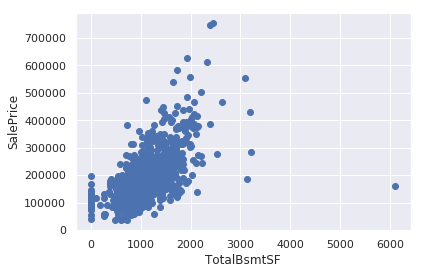

```python
x = df_train['TotalBsmtSF']
y = df_train['SalePrice']

plt.xlabel('TotalBsmtSF', fontsize=12)
plt.ylabel('SalePrice', fontsize=12)

plt.scatter(x, y)
plt.show()
```

Yup. That's way off. We'll delete it. And while we're at it, let's take a look at our other selected features.

```
1298    6110
332     3206
496     3200
523     3138
440     3094
Name: TotalBsmtSF, dtype: int64
332     3206
496     3200
523     3138
440     3094
1373    2633
Name: TotalBsmtSF, dtype: int64
```

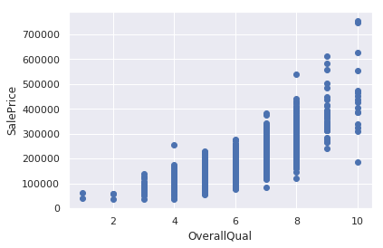

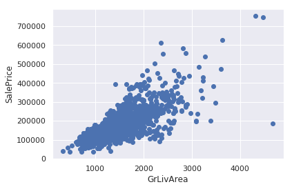

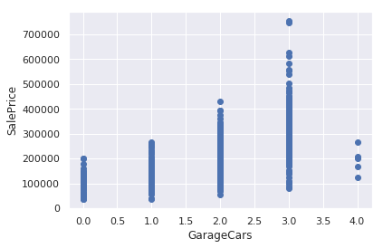

```python
print(df_train.sort_values(by='TotalBsmtSF', ascending=False)['TotalBsmtSF'].head(5))
df_train = df_train.drop(df_train[df_train['Id'] == 1299].index)
print(df_train.sort_values(by='TotalBsmtSF', ascending=False)['TotalBsmtSF'].head(5))

num_vars = ['OverallQual', 'GrLivArea', 'GarageCars']

for i in num_vars:
    x = df_train[i]
    y = df_train['SalePrice']

    plt.xlabel(i, fontsize=12)
    plt.ylabel('SalePrice', fontsize=12)

    plt.scatter(x, y)
    plt.show()
```

Seems like we've got a weird outlier in GrLivArea; let's remove it. Those four-car garages seem a bit strange too, but since they're pretty tightly bunched, we'll hang on to them.

```python
print(df_train.sort_values(by='GrLivArea', ascending=False)['GrLivArea'].head(5))
df_train = df_train.drop(df_train[df_train['Id'] == 524].index)
print(df_train.sort_values(by='GrLivArea', ascending=False)['GrLivArea'].head(5))
```

```
523     4676
1182    4476
691     4316
1169    3627
185     3608
Name: GrLivArea, dtype: int64
1182    4476
691     4316
1169    3627
185     3608
304     3493
Name: GrLivArea, dtype: int64
```